# Thinking with Data

August 6th, 2014

## Introduction

## About Me

- Who Am I?
  - Director, Program in Statistical & Data Sciences, Smith College
  - Former Statistical Analyst, **New York Mets**
- What Am I Doing Here?
  - I teach a course called "Data Science"
- Acknowledgements
  - Katherine Halvorsen
  - Nick Horton
  - Deb Nolan, Julie Legler, Danny Kaplan, Dick DeVeaux
  - http://beanumber.github.io/jsm2014.html

## Why Data Science?

- More students are taking statistics
- Most students only take one statistics course
- What do they know how to do?
  - Fit a regression model
  - Interpret coefficients
  - Divide by \(\sqrt{n}\)

## Why Data Science?

- More graduates will end up *doing* statistics
  - Not just stat majors!
- What will they be asked to do?
  - Build models
  - Interpret coefficients
  - Influence: visualize, write, speak
  - **Data Wrangling**

## Data in the Intro Course

- sampling: simple random sample
- structure: flat file (e.g. rows and columns)
- integrity: no missing data
- size: maybe a few hundred rows, one or two dozens columns
- timeframe: fixed snapshot
- type: numerical and categorical
- Do we teach it this way because:
  - that's the kind of data we generate?
  - that's the kind of data that would be generated by the models we want to fit to it?

## Data in real life

- sampling: observational
- structure: relational database, XML, scraped from WWW
- integrity: ?
- size: thousands to millions of rows, hundreds of columns
- **timeframe**: live stream, or regularly updated
- **type**: text, images, or video

## How did we get here?

- 2009: Hal Varian, Chief Economist, Google:
  - **statistician** is "sexy job in the next 10 years"
- 2012: Harvard Business Review:
  - **data scientist** is the "sexiest job of the 21st century"
- 2013: Nate Silver, FiveThirtyEight:
  - "data scientist is just a sexed up term for statistician"

## What is Data Science?

- "All hands on deck" approach to working with modern data streams
- From **statistics**:
  - understanding variation
  - visualization
  - model fitting, evaluation, interpretation
  - statistical learning
- From **computer science**
  - databases
  - programming
  - scalability, algorithms, big data
  - machine learning

## The Course

## Big Picture

- Neither exclusively statistics, nor exclusively computer science
- Not just a grab-bag of topics from each
- Fits into larger movement in stats curriculum:
  - statistical programming (Nolan and Temple Lang, 2010)
  - "data habit of mind" (Finzer, 2013)
  - tidy data, data manipulation "verbs" (Wickham, 2014)
  - statistics is reasoning, not models (Moore, 1998)
  - influence of computing power (Cobb, 2007)
  - data models vs. algorithmic models (Breiman, 2001)
- Goal: produce functional, **story-telling** data scientists

## Small Picture

- Prereqs:
  - introductory statistics
  - some programming experience
- Data Visualization
- Data Manipulation
- Computational Statistics
- Machine Learning
- Additional Topics
  - Spatial Mapping
  - Text Mining & Regular Expressions
  - Network Science
  - Big Data

## Day One

- "More Tweets, More Votes: Social Media as a Quantitative Indicator of Political Behavior" (DiGrazia, McKelvey, Bollen, Rojas, 2013)
- Argue that tweets can be used to **predict** election outcomes
- Typical **data science** project:
  - observational data scraper from Internet
  - domain knowledge + data source
  - big data problem (500 million tweets!)
  - team of researchers from different fields
- Problems?
- How would *you* do it?

## Data Visualization

- Read *Visual Display of Quantitative Information* (Tufte, 1983)
  - Present to each other
  - Critique existing data graphics
- Taxonomy of data graphics (Yau, 2013)
  - Learn to categorize visual elements in data graphics
- Examples of **data art**
  - Inspire, foster creativity
  - e.g. [Shakespeare Machine](http://vimeo.com/54858820), by Rubin, Hansen, Gorman

## Data Manipulation

- Data wrangling, manipulation, munging, massaging, etc.
  - not just data management
- "Grammar" of data manipulation (Wickham, `dplyr`, 2014)
  - select
  - filter
  - mutate
  - summarise
  - arrange
  - **group_by**

## SQL

- Learn basic SQL **querying** syntax (e.g. `SELECT`)

## SQL vs. R

- Learn to **choose** appropriate tool
- Filter by rows & columns
  - `SELECT col1, col2 FROM a WHERE col3 = 'x'`
  - `subset(a, col3 == "x", select = c(col1, col2))`
- Aggregate by rows
  - `SELECT id, sum(col1) as mysum FROM a GROUP BY id`
  - `summarise(group_by(a, id), mysum = sum(col1))`
- Combine two tables
  - `SELECT * FROM a JOIN b ON a.id = b.id`
  - `merge(x=a, y=b, by="id"))`

## Pictograms: Filter

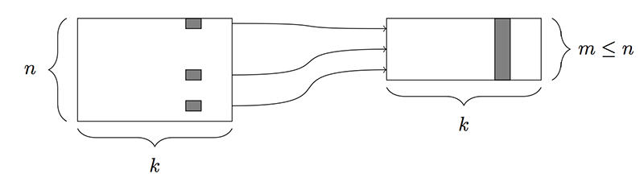

## Pictograms: Reshape

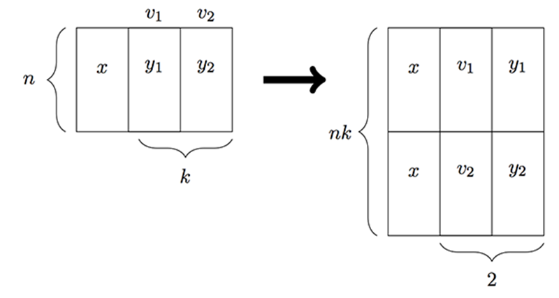

## Computational Statistics

- Not a substitute for regression course
- Two goals:
  - Variability: constructing interval estimates via resampling
  - Modeling: multiple & logistic regression, feature selection

## Machine Learning

- *An Introduction to Statistical Learning* (JWHT, 2014)
- Classification
  - Decision Trees & Random Forests
  - \(k\)-Nearest Neighbor
  - Naive Bayes
  - Artificial Neural Networks
  - Support Vector Machines
  - Ensemble Methods
- Validation
  - Cross-Validation, overfitting
  - Confusion Matrix
  - ROC curves

## Additional Topics

- Spatial Mapping
  - Choropleths, normalization, projection systems, color scales, shapefiles, KML
- Text Mining
  - Regular expressions, `grep()`
- Network Science
  - PageRank, measures of centrality, Djikstra's algorithm, **Kevin Bacon Oracle**
- Big Data
  - parallel processing, Hadoop, MapReduce

## Practice

## Project

- Semester-long, very open-ended
- Rules:
  - Your project must be centered around data
  - Your project must tell us something
  - To get an A, you must show something beyond what we've learned in class
- Deliverable: compilable [R Markdown](http://rmarkdown.rstudio.com/) document

## Data Expo

- Before projects start, but after groups formed
- A full class period, invite faculty & staff from:
  - Engineering
  - Spatial Analysis Lab
  - Administrative Technology
  - Institutional Research
  - [National Priorities Project](https://www.nationalpriorities.org/)
- Tell students about the data you work with the challenges you face
- Hugely motivating for students

## Project A: weathR

- Q: what can Twitter tell us about how the weather is perceived in different places?
  - scrape, store, and analyze Twitter data using API
  - monitor scripts over two-month period
  - create visualizations
  - wrote Shiny web application
- high technical degree of difficulty
- creativity and planning

## Project B: Smathies

- Q: what does the network of Smith math major graduates look like?
  - interviewed math faculty for major "database"
  - scraped data from MathSciNet
  - requested and obtained SQL database from [Math Genealogy Project](http://genealogy.math.ndsu.nodak.edu/)
  - used `igraph` package to construct network
  - wrote Shiny web application
- high technical degree of difficulty
- great teamwork and "soft skills"

## DataFest

- national undergraduate data analysis competition
- inaugural Five College event in spring 2014
  - Smith team won Best in Show!
  - no modeling – great visualizations
  - told a story
- **UPDATE**: national sponsorship from ASA!
- Learn more: panel discussion @ 2 pm, CC-212

## P-Valuables

> [#BestInShow#fivecollege#datafest#datascience@smithcollegepic.twitter.com/dnOAFV8t5L](https://twitter.com/hashtag/BestInShow?src=hash)

> — Ben Baumer (@BaumerBen) [March 31, 2014](https://twitter.com/BaumerBen/statuses/450430642787205122)

## Feedback

## Feedback

- overwhelmingly positive

> "We are learning useful things–enough variety that even the most seasoned of us is still seeing new things…the examples are cool…we're learning a new, better way to think and ask questions…our projects teach us a way to tackle a problem."

## Epilogue

- Student A: internship at NIST, rising senior, thesis candidate, wants to pursue a PhD in statistics/machine learning
- Student B: internship at NIST, job at MIT Lincoln Labs
- Students C & D: data scientists at MM Data Labs
- Student E: enrolled in course this fall